# Psy 350: HW 2

# Clear environment

```r
rm(list=ls())
```

# load libraries

```r
library(tidyverse)
library(yarrr)
library(psych)
```

# Read in data

```r
setwd("C:/Users/Neil/Desktop/Class folder/Fall 2018/Psy_350/Data")
yetz.data <- read.csv("PSY 350 Class Survey.csv", header = TRUE, stringsAsFactors = FALSE)
#names(yetz.data)
```

# Q1

Create a crosstab including gender and interest. In which area of psychology did more men than women express interest?

```r
table(yetz.data$interest, yetz.data$gender)
```

```
              f  m  o
  clinical    6  0  0
  cogneuro    5  2  0
  cognitive   1  1  0
  community   1  0  0
  counseling 24  3  0
  forensic   12  1  0
  health      4  2  0
  industrial  6  2  2
  other       6  2  0
  social      4  1  0
  unsure      5  1  0
```

```r
yetz.data <- yetz.data %>% mutate(
  year.f = ifelse(year == "sophomore", 1, NA),
  year.f = ifelse(year == "junior", 2, year.f),
  year.f = ifelse(year == "senior", 3, year.f),
  year.f = ifelse(year == "Other (e.g., non-degree student)",4, year.f),
  year.f = factor(year.f, levels = c(1,2,3,4), labels = c("sophomore", "junior", "senior", "other"))
)
table(yetz.data$year.f)
```

```
sophomore    junior    senior     other
        2        22        66         1
```

# Q2

What is the mean number of countries visited by students in each year (sophomore, junior, senior)? Report the numbers here (rounding to two decimals).

```r
aggregate(x = list(avg_country = yetz.data$travel), by = list(year = yetz.data$year), FUN = mean)
```

```
                              year avg_country
1                           junior    3.363636
2 Other (e.g., non-degree student)    2.000000
3                           senior    5.090909
4                        sophomore    4.000000
```

# Q3

Create a pirate plot to represent the data in your answer above. Attach your plot here.

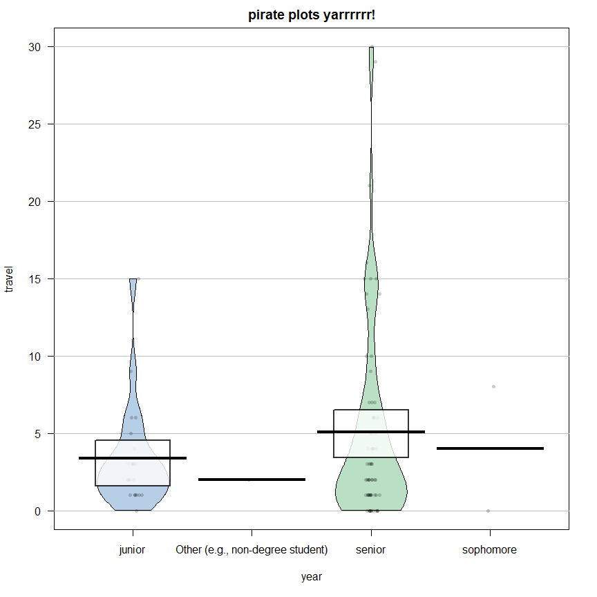

```r
pirateplot(formula = travel ~ year, data = yetz.data, xlab = "year", ylab = "travel", main = "pirate plots yarrrrrr!" )
```

# Q4

What information do you learn from the pirate plot that you didn’t get just from the means? Be specific and talk about this data in particular, not just pirate plots in general.

- The range, breadth of students in each range. The number of students

# Q5

Does number of countries visited appear to be associated with GPA? Create a scatterplot and attach it here.

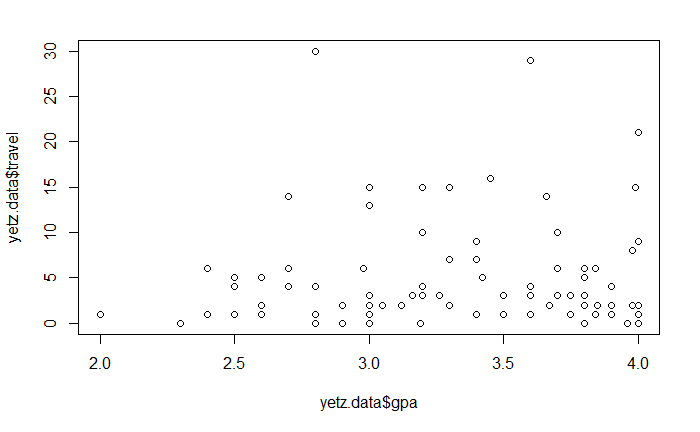

```r
plot(yetz.data$gpa, yetz.data$travel)
```

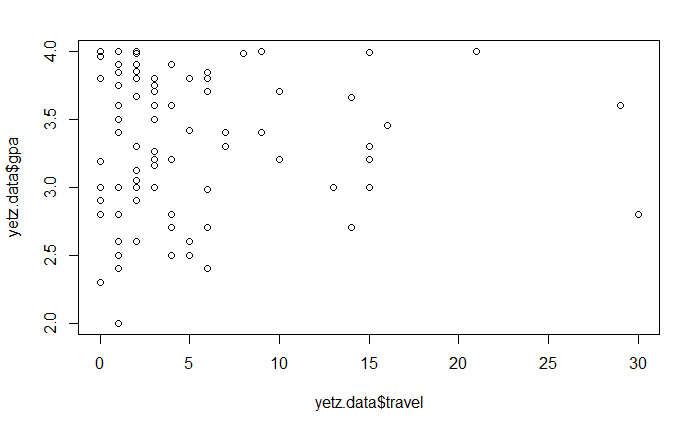

```r
plot(yetz.data$travel, yetz.data$gpa)
```

```r
cor(yetz.data$travel, yetz.data$gpa, use = "pairwise.complete.obs")
```

```
[1] 0.06482793
```

- Little correlation

# Q7

Did you need to account for missing data in order to calculate this correlation? If so, what did you do?

- Yes, use = pairwise.complete.obs

# Q8

What is the internal consistency reliability of the conscientiousness scale?

```r
psych::alpha(yetz.data[, 25:34])
```

```
Reliability analysis
Call: psych::alpha(x = yetz.data[, 25:34])

  raw_alpha std.alpha G6(smc) average_r S/N   ase mean   sd
       0.8      0.81    0.83      0.29 4.1 0.031  3.7 0.61
 median_r
     0.27

 lower alpha upper     95% confidence boundaries
0.74 0.8 0.86

 Reliability if an item is dropped:
        raw_alpha std.alpha G6(smc) average_r S/N alpha se
cons_1       0.78      0.78    0.80      0.28 3.6    0.034
cons_2       0.80      0.80    0.81      0.30 3.9    0.032
cons_3       0.77      0.77    0.79      0.27 3.4    0.036
cons_4       0.78      0.78    0.81      0.28 3.6    0.034
cons_5       0.78      0.79    0.80      0.29 3.7    0.033
cons_6       0.79      0.79    0.81      0.29 3.7    0.033
cons_7       0.78      0.78    0.80      0.29 3.6    0.035
cons_8       0.78      0.79    0.80      0.29 3.7    0.035
cons_9       0.80      0.80    0.82      0.31 4.0    0.032
cons_50      0.80      0.81    0.83      0.32 4.1    0.031
        var.r med.r
cons_1  0.018  0.26
cons_2  0.016  0.31
cons_3  0.018  0.24
cons_4  0.019  0.26
cons_5  0.016  0.28
cons_6  0.017  0.27
cons_7  0.017  0.27
cons_8  0.016  0.28
cons_9  0.017  0.31
cons_50 0.017  0.33

 Item statistics
         n raw.r std.r r.cor r.drop mean   sd
cons_1  90  0.63  0.65  0.61   0.53  3.9 0.89
cons_2  90  0.49  0.53  0.46   0.38  4.1 0.82
cons_3  90  0.72  0.71  0.69   0.61  3.2 1.11
cons_4  90  0.63  0.65  0.60   0.54  4.1 0.84
cons_5  90  0.61  0.62  0.57   0.48  3.9 1.04
cons_6  90  0.57  0.60  0.54   0.45  3.7 0.93
cons_7  90  0.67  0.64  0.60   0.54  3.0 1.23
cons_8  89  0.66  0.62  0.59   0.53  3.6 1.09
cons_9  89  0.57  0.53  0.45   0.41  3.2 1.21
cons_50 90  0.47  0.47  0.36   0.34  4.0 0.95

Non missing response frequency for each item
           1    2    3    4    5 miss
cons_1  0.00 0.12 0.10 0.57 0.21 0.01
cons_2  0.00 0.09 0.02 0.60 0.29 0.01
cons_3  0.06 0.28 0.21 0.36 0.10 0.01
cons_4  0.00 0.06 0.12 0.44 0.38 0.01
cons_5  0.02 0.11 0.11 0.43 0.32 0.01
cons_6  0.00 0.13 0.21 0.47 0.19 0.01
cons_7  0.10 0.32 0.14 0.32 0.11 0.01
cons_8  0.03 0.19 0.12 0.48 0.17 0.02
cons_9  0.09 0.26 0.10 0.44 0.11 0.02
cons_50 0.02 0.04 0.18 0.41 0.34 0.01
```

```r
yetz.data$cons <- rowMeans(yetz.data [ , c("cons_1","cons_2", "cons_3", "cons_4","cons_5","cons_6","cons_7","cons_8","cons_9","cons_50") ])
```

- internal consisteny (alpha) = 0.80

# Q9

Is this an acceptable level of reliability? How do you know?

- Yes, above 0.7 threshold

# Q10

Find the correlations among the overall conscientiousness score, the item about childhood neatness, and GPA. Report the values of all of those correlations here.

```r
cor(yetz.data[ , c("cons", "neatness", "gpa")], use = "pairwise.complete.obs")
```

```
              cons    neatness         gpa
cons     1.0000000  0.33644942  0.11339774
neatness 0.3364494  1.00000000 -0.03052847
gpa      0.1133977 -0.03052847  1.00000000
```

# Q11

Find scatterplots of those correlations and upload them here (remember that you should be able to get all of the correlations from one line of script - no need to plot each correlation separately).

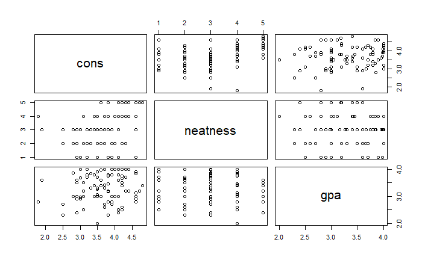

```r
plot(yetz.data[ , c("cons", "neatness", "gpa")])
```

```r
yetz.data %>%
  select(cons, neatness, gpa) %>%
  describe()
```

```
         vars  n mean   sd median trimmed  mad min max range  skew kurtosis   se
cons        1 88 3.68 0.61   3.75    3.70 0.67 1.8 4.8     3 -0.56     0.24 0.07
neatness    2 91 3.03 1.17   3.00    3.04 1.48 1.0 5.0     4  0.02    -0.87 0.12
gpa         3 90 3.30 0.51   3.30    3.33 0.59 2.0 4.0     2 -0.32    -0.88 0.05
```